# Optimal Treatment Analysis

## Outcome Variable

**Outcome Variable:** haz

## Predictor Variables

**Intervention Variable:** mbmi

**Adjustment Set:**

- arm
- W_mage
- meducyrs
- feducyrs
- hhwealth_quart
- brthmon
- W_parity
- impfloor
- impsan
- safeh20
- delta_W_mage
- delta_meducyrs
- delta_feducyrs
- delta_hhwealth_quart
- delta_brthmon
- delta_W_parity
- delta_impfloor
- delta_impsan
- delta_safeh20

## Stratifying Variables

The analysis was stratified on these variable(s):

- agecat
- studyid
- country

## Data Summary

| agecat | studyid | country | mbmi | n_cell | n |
| --- | --- | --- | --- | --- | --- |
| Birth | JiVitA-3 | BANGLADESH | Normal weight | 13720 | 22355 |
| Birth | JiVitA-3 | BANGLADESH | Underweight | 8635 | 22355 |
| Birth | MAL-ED | BANGLADESH | Normal weight | 194 | 222 |
| Birth | MAL-ED | BANGLADESH | Underweight | 28 | 222 |
| Birth | MAL-ED | BRAZIL | Normal weight | 59 | 64 |
| Birth | MAL-ED | BRAZIL | Underweight | 5 | 64 |
| Birth | MAL-ED | INDIA | Normal weight | 35 | 43 |
| Birth | MAL-ED | INDIA | Underweight | 8 | 43 |
| Birth | MAL-ED | NEPAL | Normal weight | 27 | 27 |
| Birth | MAL-ED | NEPAL | Underweight | 0 | 27 |
| Birth | MAL-ED | PERU | Normal weight | 221 | 226 |
| Birth | MAL-ED | PERU | Underweight | 5 | 226 |
| Birth | MAL-ED | SOUTH AFRICA | Normal weight | 98 | 101 |
| Birth | MAL-ED | SOUTH AFRICA | Underweight | 3 | 101 |
| Birth | MAL-ED | TANZANIA, UNITED REPUBLIC OF | Normal weight | 115 | 122 |
| Birth | MAL-ED | TANZANIA, UNITED REPUBLIC OF | Underweight | 7 | 122 |
| Birth | NIH-Birth | BANGLADESH | Normal weight | 506 | 608 |
| Birth | NIH-Birth | BANGLADESH | Underweight | 102 | 608 |
| Birth | NIH-Crypto | BANGLADESH | Normal weight | 663 | 729 |
| Birth | NIH-Crypto | BANGLADESH | Underweight | 66 | 729 |
| Birth | PROBIT | BELARUS | Normal weight | 13203 | 13726 |
| Birth | PROBIT | BELARUS | Underweight | 523 | 13726 |
| Birth | PROVIDE | BANGLADESH | Normal weight | 418 | 517 |
| Birth | PROVIDE | BANGLADESH | Underweight | 99 | 517 |
| Birth | SAS-CompFeed | INDIA | Normal weight | 830 | 1135 |
| Birth | SAS-CompFeed | INDIA | Underweight | 305 | 1135 |
| Birth | ZVITAMBO | ZIMBABWE | Normal weight | 9162 | 9672 |
| Birth | ZVITAMBO | ZIMBABWE | Underweight | 510 | 9672 |
| 6 months | JiVitA-3 | BANGLADESH | Normal weight | 10311 | 16760 |
| 6 months | JiVitA-3 | BANGLADESH | Underweight | 6449 | 16760 |

[output cut: 60 more lines]

The following strata were considered:

- agecat: 24 months, studyid: JiVitA-3, country: BANGLADESH
- agecat: 24 months, studyid: LCNI-5, country: MALAWI
- agecat: 24 months, studyid: MAL-ED, country: BANGLADESH
- agecat: 24 months, studyid: MAL-ED, country: BRAZIL
- agecat: 24 months, studyid: MAL-ED, country: INDIA
- agecat: 24 months, studyid: MAL-ED, country: NEPAL
- agecat: 24 months, studyid: MAL-ED, country: PERU
- agecat: 24 months, studyid: MAL-ED, country: SOUTH AFRICA
- agecat: 24 months, studyid: MAL-ED, country: TANZANIA, UNITED REPUBLIC OF
- agecat: 24 months, studyid: NIH-Birth, country: BANGLADESH
- agecat: 24 months, studyid: NIH-Crypto, country: BANGLADESH
- agecat: 24 months, studyid: PROBIT, country: BELARUS
- agecat: 24 months, studyid: PROVIDE, country: BANGLADESH
- agecat: 24 months, studyid: TanzaniaChild2, country: TANZANIA, UNITED REPUBLIC OF
- agecat: 24 months, studyid: ZVITAMBO, country: ZIMBABWE
- agecat: 6 months, studyid: JiVitA-3, country: BANGLADESH
- agecat: 6 months, studyid: LCNI-5, country: MALAWI
- agecat: 6 months, studyid: MAL-ED, country: BANGLADESH
- agecat: 6 months, studyid: MAL-ED, country: BRAZIL
- agecat: 6 months, studyid: MAL-ED, country: INDIA
- agecat: 6 months, studyid: MAL-ED, country: NEPAL
- agecat: 6 months, studyid: MAL-ED, country: PERU
- agecat: 6 months, studyid: MAL-ED, country: SOUTH AFRICA
- agecat: 6 months, studyid: MAL-ED, country: TANZANIA, UNITED REPUBLIC OF
- agecat: 6 months, studyid: NIH-Birth, country: BANGLADESH
- agecat: 6 months, studyid: NIH-Crypto, country: BANGLADESH
- agecat: 6 months, studyid: PROBIT, country: BELARUS
- agecat: 6 months, studyid: PROVIDE, country: BANGLADESH
- agecat: 6 months, studyid: SAS-CompFeed, country: INDIA
- agecat: 6 months, studyid: TanzaniaChild2, country: TANZANIA, UNITED REPUBLIC OF
- agecat: 6 months, studyid: ZVITAMBO, country: ZIMBABWE
- agecat: Birth, studyid: JiVitA-3, country: BANGLADESH
- agecat: Birth, studyid: MAL-ED, country: BANGLADESH
- agecat: Birth, studyid: MAL-ED, country: BRAZIL
- agecat: Birth, studyid: MAL-ED, country: INDIA
- agecat: Birth, studyid: MAL-ED, country: NEPAL
- agecat: Birth, studyid: MAL-ED, country: PERU
- agecat: Birth, studyid: MAL-ED, country: SOUTH AFRICA
- agecat: Birth, studyid: MAL-ED, country: TANZANIA, UNITED REPUBLIC OF
- agecat: Birth, studyid: NIH-Birth, country: BANGLADESH
- agecat: Birth, studyid: NIH-Crypto, country: BANGLADESH
- agecat: Birth, studyid: PROBIT, country: BELARUS
- agecat: Birth, studyid: PROVIDE, country: BANGLADESH
- agecat: Birth, studyid: SAS-CompFeed, country: INDIA
- agecat: Birth, studyid: ZVITAMBO, country: ZIMBABWE

### Dropped Strata

Some strata were dropped due to rare outcomes:

- agecat: Birth, studyid: MAL-ED, country: NEPAL
- agecat: Birth, studyid: MAL-ED, country: SOUTH AFRICA
- agecat: 6 months, studyid: MAL-ED, country: NEPAL
- agecat: 24 months, studyid: MAL-ED, country: NEPAL
- agecat: 24 months, studyid: MAL-ED, country: PERU
- agecat: 24 months, studyid: TanzaniaChild2, country: TANZANIA, UNITED REPUBLIC OF

## Methods Detail

We’re interested in the causal parameters $E[Y_a]$ for all values of $a \in \mathcal{A}$. These parameters represent the mean outcome if, possibly contrary to fact, we intervened to set all units to have $A=a$. Under the randomization and positivity assumptions, these are identified by the statistical parameters $\psi_a=E_W[E_{Y|A,W}(Y|A=a,W)]$. In addition, we’re interested in the mean of $Y$, $E[Y]$ under no intervention (the observed mean). We will estimate these parameters by using SuperLearner to fit the relevant likelihood factors – $E_{Y|A,W}(Y|A=a,W)$ and $p(A=a|W)$, and then updating our likelihood fit using a joint TMLE.

For unadjusted analyses ($W=\{\}$), initial likelihoods were estimated using Lrnr_glm to estimate the simple $E(Y|A)$ and Lrnr_mean to estimate $p(A)$. For adjusted analyses, a small library containing Lrnr_glmnet, Lrnr_xgboost, and Lrnr_mean was used.

Having estimated these parameters, we will then use the delta method to estimate relative risks and attributable risks relative to a prespecified baseline level of $A$.

# Results Detail

## Results Plots

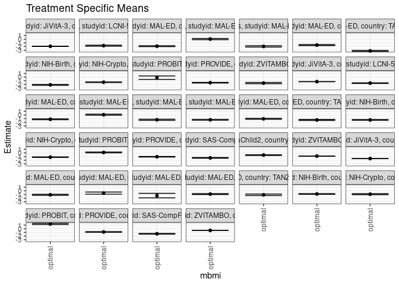

## Results Table

### Parameter: TSM

| agecat | studyid | country | intervention_level | baseline_level | estimate | ci_lower | ci_upper |
| --- | --- | --- | --- | --- | --- | --- | --- |
| Birth | JiVitA-3 | BANGLADESH | optimal | observed | -1.5453100 | -1.5732453 | -1.5173747 |
| Birth | MAL-ED | BANGLADESH | optimal | observed | -1.0865531 | -1.2319259 | -0.9411803 |
| Birth | MAL-ED | BRAZIL | optimal | observed | -0.6219516 | -0.9112785 | -0.3326247 |
| Birth | MAL-ED | INDIA | optimal | observed | -1.3030369 | -1.9240826 | -0.6819912 |
| Birth | MAL-ED | PERU | optimal | observed | -0.8867001 | -1.0063170 | -0.7670833 |
| Birth | MAL-ED | TANZANIA, UNITED REPUBLIC OF | optimal | observed | -1.0902812 | -1.3049823 | -0.8755800 |
| Birth | NIH-Birth | BANGLADESH | optimal | observed | -0.8605138 | -0.9556343 | -0.7653933 |
| Birth | NIH-Crypto | BANGLADESH | optimal | observed | -0.9205893 | -1.0511386 | -0.7900399 |
| Birth | PROBIT | BELARUS | optimal | observed | 1.3153561 | 1.1487152 | 1.4819969 |
| Birth | PROVIDE | BANGLADESH | optimal | observed | -0.8764058 | -0.9699885 | -0.7828232 |
| Birth | SAS-CompFeed | INDIA | optimal | observed | -1.3735982 | -1.4693848 | -1.2778115 |
| Birth | ZVITAMBO | ZIMBABWE | optimal | observed | -0.4612231 | -0.4862983 | -0.4361479 |
| 6 months | JiVitA-3 | BANGLADESH | optimal | observed | -1.2434394 | -1.2738664 | -1.2130124 |
| 6 months | LCNI-5 | MALAWI | optimal | observed | -1.6457557 | -1.7240445 | -1.5674669 |
| 6 months | MAL-ED | BANGLADESH | optimal | observed | -1.1657821 | -1.2910305 | -1.0405337 |
| 6 months | MAL-ED | BRAZIL | optimal | observed | 0.0704474 | -0.0785783 | 0.2194730 |
| 6 months | MAL-ED | INDIA | optimal | observed | -1.2977208 | -1.4531097 | -1.1423319 |
| 6 months | MAL-ED | PERU | optimal | observed | -1.3102019 | -1.4186155 | -1.2017884 |
| 6 months | MAL-ED | SOUTH AFRICA | optimal | observed | -1.0470818 | -1.1781844 | -0.9159793 |
| 6 months | MAL-ED | TANZANIA, UNITED REPUBLIC OF | optimal | observed | -1.3520410 | -1.4759969 | -1.2280851 |
| 6 months | NIH-Birth | BANGLADESH | optimal | observed | -1.3463231 | -1.4413742 | -1.2512720 |
| 6 months | NIH-Crypto | BANGLADESH | optimal | observed | -1.1627058 | -1.2368031 | -1.0886085 |
| 6 months | PROBIT | BELARUS | optimal | observed | 0.1272155 | 0.0142715 | 0.2401595 |
| 6 months | PROVIDE | BANGLADESH | optimal | observed | -1.0465393 | -1.1299460 | -0.9631326 |
| 6 months | SAS-CompFeed | INDIA | optimal | observed | -1.3557066 | -1.4534862 | -1.2579269 |
| 6 months | TanzaniaChild2 | TANZANIA, UNITED REPUBLIC OF | optimal | observed | -0.5922350 | -0.6785670 | -0.5059031 |
| 6 months | ZVITAMBO | ZIMBABWE | optimal | observed | -0.8680845 | -0.8962748 | -0.8398941 |
| 24 months | JiVitA-3 | BANGLADESH | optimal | observed | -1.9426342 | -1.9824172 | -1.9028512 |
| 24 months | LCNI-5 | MALAWI | optimal | observed | -1.7674374 | -1.9015395 | -1.6333353 |
| 24 months | MAL-ED | BANGLADESH | optimal | observed | -1.9107544 | -2.0418821 | -1.7796268 |
| 24 months | MAL-ED | BRAZIL | optimal | observed | 0.0261715 | -0.1438094 | 0.1961524 |
| 24 months | MAL-ED | INDIA | optimal | observed | -1.9722601 | -2.1633988 | -1.7811213 |
| 24 months | MAL-ED | SOUTH AFRICA | optimal | observed | -1.6125210 | -1.7500860 | -1.4749559 |
| 24 months | MAL-ED | TANZANIA, UNITED REPUBLIC OF | optimal | observed | -3.1968857 | -3.3541870 | -3.0395843 |
| 24 months | NIH-Birth | BANGLADESH | optimal | observed | -2.1266851 | -2.2398878 | -2.0134824 |
| 24 months | NIH-Crypto | BANGLADESH | optimal | observed | -1.4045007 | -1.4909979 | -1.3180036 |
| 24 months | PROBIT | BELARUS | optimal | observed | -0.1599580 | -0.6302805 | 0.3103645 |
| 24 months | PROVIDE | BANGLADESH | optimal | observed | -1.5318970 | -1.6216611 | -1.4421328 |
| 24 months | ZVITAMBO | ZIMBABWE | optimal | observed | -1.6374058 | -1.8074109 | -1.4674007 |

### Parameter: E(Y)

| agecat | studyid | country | intervention_level | baseline_level | estimate | ci_lower | ci_upper |
| --- | --- | --- | --- | --- | --- | --- | --- |
| Birth | JiVitA-3 | BANGLADESH | observed | observed | -1.5893196 | -1.6086080 | -1.5700313 |
| Birth | MAL-ED | BANGLADESH | observed | observed | -1.0778829 | -1.2122580 | -0.9435077 |
| Birth | MAL-ED | BRAZIL | observed | observed | -0.6884375 | -0.9678371 | -0.4090379 |
| Birth | MAL-ED | INDIA | observed | observed | -1.2302326 | -1.5393614 | -0.9211037 |
| Birth | MAL-ED | PERU | observed | observed | -0.9051327 | -1.0238686 | -0.7863969 |
| Birth | MAL-ED | TANZANIA, UNITED REPUBLIC OF | observed | observed | -1.1364754 | -1.3478823 | -0.9250686 |
| Birth | NIH-Birth | BANGLADESH | observed | observed | -0.9310197 | -1.0197391 | -0.8423003 |
| Birth | NIH-Crypto | BANGLADESH | observed | observed | -0.9089163 | -0.9806324 | -0.8372002 |
| Birth | PROBIT | BELARUS | observed | observed | 1.3118585 | 1.1523374 | 1.4713797 |
| Birth | PROVIDE | BANGLADESH | observed | observed | -0.8925145 | -0.9687201 | -0.8163089 |
| Birth | SAS-CompFeed | INDIA | observed | observed | -1.4438150 | -1.5337502 | -1.3538797 |
| Birth | ZVITAMBO | ZIMBABWE | observed | observed | -0.4764413 | -0.5009156 | -0.4519670 |
| 6 months | JiVitA-3 | BANGLADESH | observed | observed | -1.3140048 | -1.3371141 | -1.2908955 |
| 6 months | LCNI-5 | MALAWI | observed | observed | -1.6577751 | -1.7275296 | -1.5880207 |
| 6 months | MAL-ED | BANGLADESH | observed | observed | -1.2049931 | -1.3222136 | -1.0877726 |
| 6 months | MAL-ED | BRAZIL | observed | observed | 0.0497516 | -0.0948051 | 0.1943083 |
| 6 months | MAL-ED | INDIA | observed | observed | -1.2059574 | -1.3243030 | -1.0876119 |
| 6 months | MAL-ED | PERU | observed | observed | -1.3241023 | -1.4325083 | -1.2156964 |
| 6 months | MAL-ED | SOUTH AFRICA | observed | observed | -1.0727443 | -1.2024880 | -0.9430006 |
| 6 months | MAL-ED | TANZANIA, UNITED REPUBLIC OF | observed | observed | -1.3687449 | -1.4907629 | -1.2467270 |
| 6 months | NIH-Birth | BANGLADESH | observed | observed | -1.4073821 | -1.4960598 | -1.3187043 |
| 6 months | NIH-Crypto | BANGLADESH | observed | observed | -1.1986783 | -1.2700937 | -1.1272630 |
| 6 months | PROBIT | BELARUS | observed | observed | 0.1076224 | 0.0168411 | 0.1984037 |
| 6 months | PROVIDE | BANGLADESH | observed | observed | -1.0895301 | -1.1639589 | -1.0151013 |
| 6 months | SAS-CompFeed | INDIA | observed | observed | -1.4068893 | -1.4981242 | -1.3156543 |
| 6 months | TanzaniaChild2 | TANZANIA, UNITED REPUBLIC OF | observed | observed | -0.5405711 | -0.5899965 | -0.4911457 |
| 6 months | ZVITAMBO | ZIMBABWE | observed | observed | -0.8800508 | -0.9074511 | -0.8526506 |
| 24 months | JiVitA-3 | BANGLADESH | observed | observed | -2.0137632 | -2.0415122 | -1.9860142 |
| 24 months | LCNI-5 | MALAWI | observed | observed | -1.8851820 | -1.9664818 | -1.8038822 |
| 24 months | MAL-ED | BANGLADESH | observed | observed | -1.9783962 | -2.1050210 | -1.8517715 |
| 24 months | MAL-ED | BRAZIL | observed | observed | 0.0059127 | -0.1637934 | 0.1756188 |
| 24 months | MAL-ED | INDIA | observed | observed | -1.8844690 | -2.0097879 | -1.7591502 |
| 24 months | MAL-ED | SOUTH AFRICA | observed | observed | -1.6432229 | -1.7795844 | -1.5068615 |
| 24 months | MAL-ED | TANZANIA, UNITED REPUBLIC OF | observed | observed | -2.6455607 | -2.7807256 | -2.5103959 |
| 24 months | NIH-Birth | BANGLADESH | observed | observed | -2.2190579 | -2.3217459 | -2.1163699 |
| 24 months | NIH-Crypto | BANGLADESH | observed | observed | -1.4412646 | -1.5249156 | -1.3576135 |
| 24 months | PROBIT | BELARUS | observed | observed | -0.1444149 | -0.4258602 | 0.1370304 |
| 24 months | PROVIDE | BANGLADESH | observed | observed | -1.6002600 | -1.6836163 | -1.5169036 |
| 24 months | ZVITAMBO | ZIMBABWE | observed | observed | -1.5983212 | -1.6605141 | -1.5361283 |

### Parameter: PAR

| agecat | studyid | country | intervention_level | baseline_level | estimate | ci_lower | ci_upper |
| --- | --- | --- | --- | --- | --- | --- | --- |
| Birth | JiVitA-3 | BANGLADESH | optimal | observed | -0.0440096 | -0.0643042 | -0.0237150 |
| Birth | MAL-ED | BANGLADESH | optimal | observed | 0.0086702 | -0.0429679 | 0.0603083 |
| Birth | MAL-ED | BRAZIL | optimal | observed | -0.0664859 | -0.1535518 | 0.0205800 |
| Birth | MAL-ED | INDIA | optimal | observed | 0.0728043 | -0.4953320 | 0.6409407 |
| Birth | MAL-ED | PERU | optimal | observed | -0.0184326 | -0.0410674 | 0.0042021 |
| Birth | MAL-ED | TANZANIA, UNITED REPUBLIC OF | optimal | observed | -0.0461942 | -0.1100059 | 0.0176174 |
| Birth | NIH-Birth | BANGLADESH | optimal | observed | -0.0705059 | -0.1139572 | -0.0270546 |
| Birth | NIH-Crypto | BANGLADESH | optimal | observed | 0.0116730 | -0.0978082 | 0.1211542 |
| Birth | PROBIT | BELARUS | optimal | observed | -0.0034976 | -0.0219532 | 0.0149581 |
| Birth | PROVIDE | BANGLADESH | optimal | observed | -0.0161087 | -0.0734502 | 0.0412328 |
| Birth | SAS-CompFeed | INDIA | optimal | observed | -0.0702168 | -0.0932117 | -0.0472220 |
| Birth | ZVITAMBO | ZIMBABWE | optimal | observed | -0.0152182 | -0.0212845 | -0.0091519 |
| 6 months | JiVitA-3 | BANGLADESH | optimal | observed | -0.0705654 | -0.0911071 | -0.0500237 |
| 6 months | LCNI-5 | MALAWI | optimal | observed | -0.0120194 | -0.0419962 | 0.0179574 |
| 6 months | MAL-ED | BANGLADESH | optimal | observed | -0.0392110 | -0.0838103 | 0.0053883 |
| 6 months | MAL-ED | BRAZIL | optimal | observed | -0.0206958 | -0.0454964 | 0.0041049 |
| 6 months | MAL-ED | INDIA | optimal | observed | 0.0917633 | -0.0182528 | 0.2017795 |
| 6 months | MAL-ED | PERU | optimal | observed | -0.0139004 | -0.0381395 | 0.0103387 |
| 6 months | MAL-ED | SOUTH AFRICA | optimal | observed | -0.0256625 | -0.0513486 | 0.0000237 |
| 6 months | MAL-ED | TANZANIA, UNITED REPUBLIC OF | optimal | observed | -0.0167039 | -0.0524738 | 0.0190659 |
| 6 months | NIH-Birth | BANGLADESH | optimal | observed | -0.0610589 | -0.1047186 | -0.0173993 |
| 6 months | NIH-Crypto | BANGLADESH | optimal | observed | -0.0359725 | -0.0625574 | -0.0093876 |
| 6 months | PROBIT | BELARUS | optimal | observed | -0.0195931 | -0.0590565 | 0.0198703 |
| 6 months | PROVIDE | BANGLADESH | optimal | observed | -0.0429908 | -0.0756406 | -0.0103410 |
| 6 months | SAS-CompFeed | INDIA | optimal | observed | -0.0511827 | -0.0888962 | -0.0134692 |
| 6 months | TanzaniaChild2 | TANZANIA, UNITED REPUBLIC OF | optimal | observed | 0.0516639 | -0.0206521 | 0.1239799 |
| 6 months | ZVITAMBO | ZIMBABWE | optimal | observed | -0.0119664 | -0.0182399 | -0.0056929 |
| 24 months | JiVitA-3 | BANGLADESH | optimal | observed | -0.0711290 | -0.1007204 | -0.0415376 |
| 24 months | LCNI-5 | MALAWI | optimal | observed | -0.1177446 | -0.2315001 | -0.0039891 |
| 24 months | MAL-ED | BANGLADESH | optimal | observed | -0.0676418 | -0.1246679 | -0.0106158 |
| 24 months | MAL-ED | BRAZIL | optimal | observed | -0.0202588 | -0.0642726 | 0.0237550 |
| 24 months | MAL-ED | INDIA | optimal | observed | 0.0877910 | -0.0352947 | 0.2108768 |
| 24 months | MAL-ED | SOUTH AFRICA | optimal | observed | -0.0307020 | -0.0592637 | -0.0021403 |
| 24 months | MAL-ED | TANZANIA, UNITED REPUBLIC OF | optimal | observed | 0.5513249 | 0.3991087 | 0.7035411 |
| 24 months | NIH-Birth | BANGLADESH | optimal | observed | -0.0923728 | -0.1421487 | -0.0425970 |
| 24 months | NIH-Crypto | BANGLADESH | optimal | observed | -0.0367638 | -0.0648347 | -0.0086929 |
| 24 months | PROBIT | BELARUS | optimal | observed | 0.0155431 | -0.3087852 | 0.3398714 |
| 24 months | PROVIDE | BANGLADESH | optimal | observed | -0.0683630 | -0.1092202 | -0.0275057 |
| 24 months | ZVITAMBO | ZIMBABWE | optimal | observed | 0.0390846 | -0.1202405 | 0.1984098 |